# Population Pyramids I

Reading, manipulating, smoothing and plotting

Pedro Delicado

Simposio de Estadística, Ibagué, Colombia. 2023

# 1 Poulation Pyramids. Countries of the World

## 1.1 Reading data from United Nations

Population data have been [downloaded from the web page](https://population.un.org/wpp/Download/Standard/Population/) of

> United Nations, Department of Economic and Social Affairs, Population Division (2022). *World Population Prospects 2022, Online Edition*.

Several data formats are available there. We are working with these data:

**Male and Female population by five-year age group, region, subregion and country, annually for 1950-2100 (thousands)**

Two files have been downloaded:

```r
if (!file.exists("WPP2022_POP_F02_2_POPULATION_5-YEAR_AGE_GROUPS.RData")){
 library(readxl)
  pp_names <- read_xlsx(
    "WPP2022_POP_F02_2_POPULATION_5-YEAR_AGE_GROUPS_MALE.xlsx",
    sheet="Estimates", skip=16, n_max = 1)
  ppM <- read_xlsx(
    "WPP2022_POP_F02_2_POPULATION_5-YEAR_AGE_GROUPS_MALE.xlsx",
    sheet="Estimates", skip=1749, col_names = names(pp_names))
  ppF <- read_xlsx(
    "WPP2022_POP_F02_3_POPULATION_5-YEAR_AGE_GROUPS_FEMALE.xlsx",
    sheet="Estimates", skip=1749, col_names = names(pp_names))

  # Removing rows corresponding to groups of countries or regions
  IndGroups <- which(is.na(ppM$`ISO2 Alpha-code`))
  ppM <- ppM[-IndGroups,]
  ppF <- ppF[-IndGroups,]
  rm(IndGroups)
  save(ppM,ppF,file="WPP2022_POP_F02_2_POPULATION_5-YEAR_AGE_GROUPS.RData")
}else{
  load("WPP2022_POP_F02_2_POPULATION_5-YEAR_AGE_GROUPS.RData")
}
```

```r
CtryName <- unique(ppM$`Region, subregion, country or area *`)
CtryISO3 <- unique(ppM$`ISO3 Alpha-code`)
CtryISO2 <- unique(ppM$`ISO2 Alpha-code`)
Year <- unique(ppM$Year)
AgeCh <- names(ppM)[12:32]

nc <- length(CtryISO2)
ny <- length(Year)
nag <- length(AgeCh)
Age <- (1:nag)*5 - 2.5

Country <- data.frame(Name=CtryName, ISO3=CtryISO3, ISO2=CtryISO2)
row.names(Country) <- CtryISO2
```

# 2 Ploting and manipulating population pyramids

As an example, here we have the population pyramids of Colombia and Spain for year 2021:

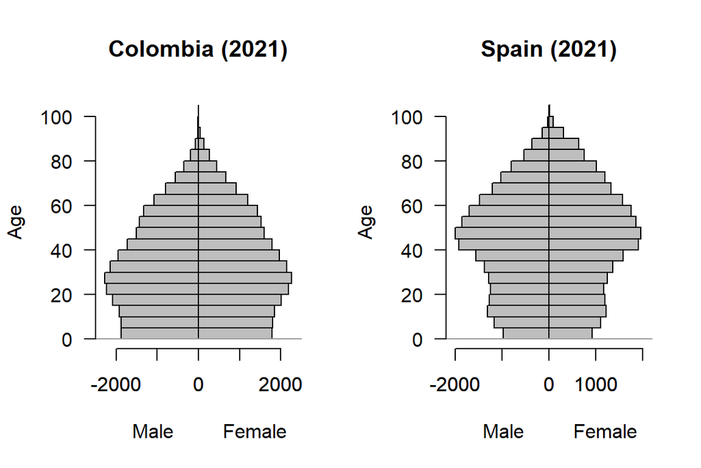

```r
par(mfrow=c(1,2))
year <- 2021
for (ctry in c('CO','ES')){
  row_ctry <- which((ppM$`ISO2 Alpha-code`==ctry)&(ppM$Year==year))
  name.country <- Country[ctry,1]
  male   <- as.numeric(ppM[row_ctry, 12:32])
  female <- as.numeric(ppF[row_ctry, 12:32])
  max_x <- max(c(male, female))
  barplot(-male,width=5,hor=T,beside=F,space=0,xlim=max_x*1.1*c(-1,1),
          las=1, main=paste(name.country," (",year,")",sep=""),
          ylab="Age",
          xlab="    Male         Female")
  barplot(female,width=5,hor=T,beside=F,space=0,add=TRUE)
  abline(h=0,col=8)
  axis(2,labels=NULL,las=1)
}
```

We store the population pyramids data as 3 dimensional arrays, **country** by **calendar_year** by **age**:
$$\{X_M(c,t,a), X_F(c,t,a)\},$$
where $c$ indicates the country (there are a total of 236 countries or areas), $t\in \{1950,\dots,2021\}$ indicates the calendar year (72 years), and $a\in\{2.5:5:102.5\}$ indicates the mid-point of each age interval,
$$[0,5), \dots, [95,100),[100,\infty),$$
except the last one.

In fact, we pack together the Males and Females cubes into a unique large cube. For $a=-102.5:5:102.5$, let
$$X(c,t,a)=
\left\{
\begin{array}{lcl}
X_M(c,t,-a) & if & a<0 \\
X_F(c,t,a) & if & a>0
\end{array}
\right.$$

From the original population counts, we define **relative population pyramids**:
$$R(c,t,a)=\frac{X(c,t,a)}{\sum_{s=-102.5}^{102.5} X(c,t,s)}.$$

```r
egAge <- c(-rev(Age),Age)

PopPyr <- array(data=NA, dim=c(nc,ny,2*nag),
                    dimnames = list(Country=CtryISO2,
                                    Year=as.character(Year),
                                    M_agAge_F=c(paste0("M_",rev(AgeCh)),
                                      paste0("F_",AgeCh)) ) )
PopPyrRel <- PopPyr
#c("Country", "Year", "-Age (M)        Age (F)")
for (i in (1:nc)){
  Ind_ctry <- which(ppM$`ISO2 Alpha-code`==CtryISO2[i])
  PopPyr[i,,nag:1] <- as.matrix(ppM[Ind_ctry,12:32])
  PopPyr[i,,nag+(1:nag)] <- as.matrix(ppF[Ind_ctry,12:32])
  PopPyrRel[i,,] <- t(apply(PopPyr[i,,],1,function(x){x/sum(x)}))
}
```

We do it for Colombia and Spain, year 2021:

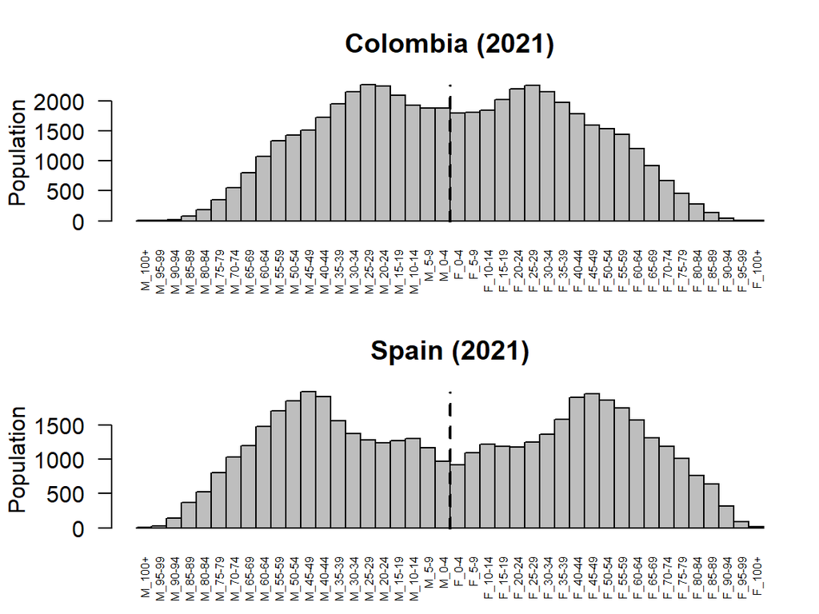

```r
par(mfrow=c(2,1), mar=c(3, 4, 3, 1) + 0.1)
year <- 2021
for (ctry in c('CO','ES')){
  name.country <- Country[ctry,1]
  barplot(PopPyr[ctry,as.character(year),],width=5,
          hor=F,beside=F,space=0,
          las=2, main=paste(name.country," (",year,")",sep=""),
          ylab="Population",
          xlab="",cex.names=.5)
  abline(v=105,lty=2,lwd=2)
}
```

Now, we plot the relative population pyramids for these two countries, and then we show the corresponding age-symmetric population histograms:

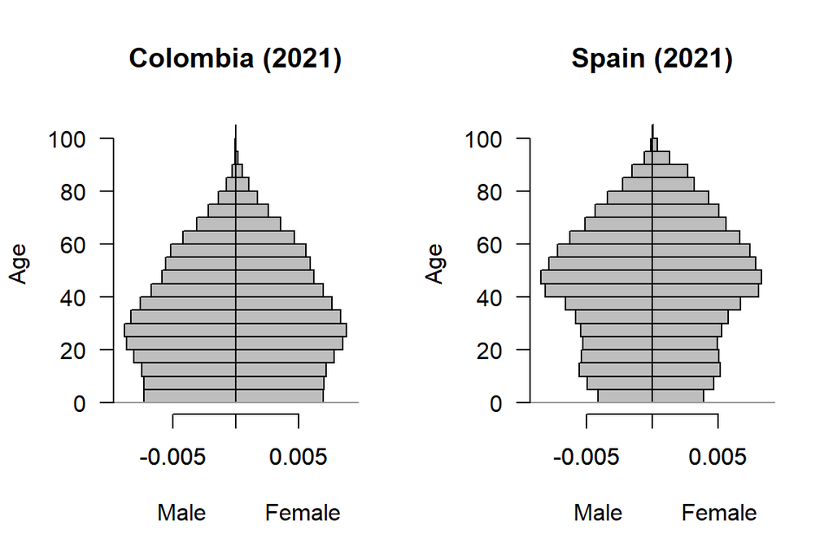

```r
par(mfrow=c(1,2))
year <- 2021
for (ctry in c('CO','ES')){
  name.country <- Country[ctry,1]
  male  <-as.numeric(PopPyrRel[ctry,as.character(year),nag:1])/5
  female<-as.numeric(PopPyrRel[ctry,as.character(year),nag+(1:nag)])/5
  max_x <- max(c(male, female))
  barplot(-male,width=5,hor=T,beside=F,space=0,
          xlim=max_x*1.1*c(-1,1),
          las=1, main=paste(name.country," (",year,")",sep=""),
          ylab="Age",
          xlab="    Male         Female")
  barplot(female,width=5,hor=T,beside=F,space=0,add=TRUE)
  abline(h=0,col=8)
  axis(2,labels=NULL,las=1)
}
```

Observe that the values of the population pyramids are now in the *density scale*: the sum of the areas of a population pyramid bars is equal to 1.

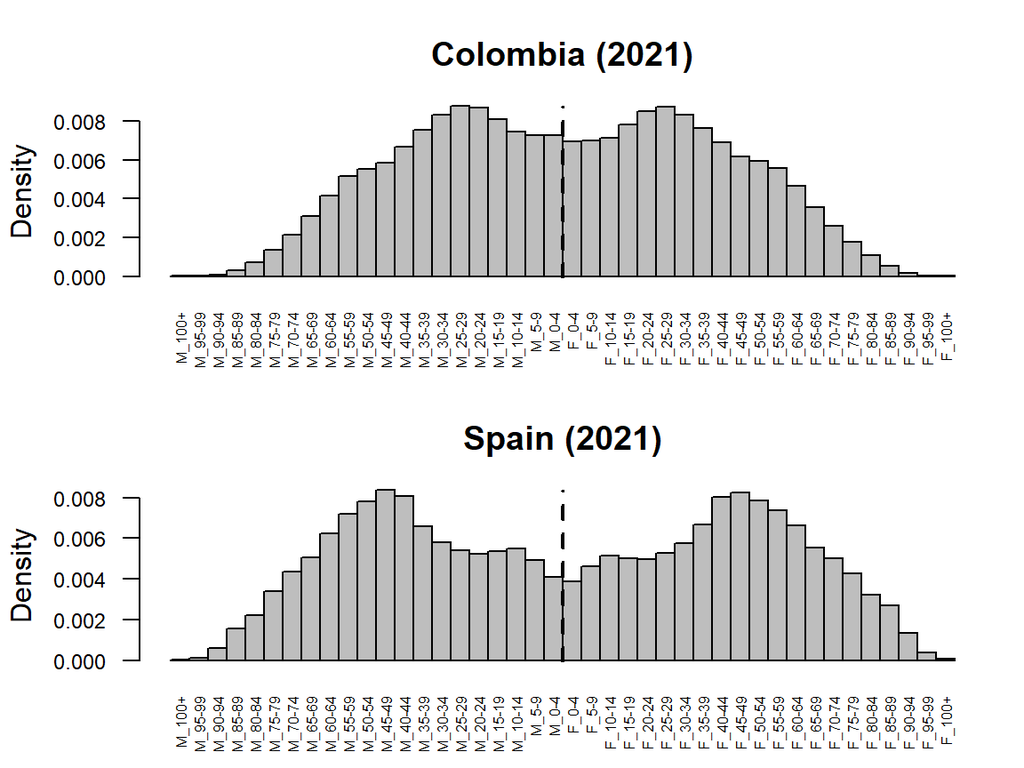

```r
par(mfrow=c(2,1), mar=c(3, 4, 3, 1) + 0.1)
year <- 2021
for (ctry in c('CO','ES')){
  name.country <- Country[ctry,1]
  barplot(PopPyrRel[ctry,as.character(year),]/5,width=5,
          hor=F,beside=F,space=0,
          las=2, main=paste(name.country," (",year,")",sep=""),
          ylab="Density",
          xlab="",cex.names=.5, cex.axis = .75)
  abline(v=105,lty=2,lwd=2)
}
```

Observe that the values of the age-symmetric population histograms are now in the *density scale*: the sum of the areas of an age-symmetric population histogram bars is equal to 1. That is, the integral of an age-symmetric population histogram is equal to 1.

Therefore, **age-symmetric population histograms are density functions**.

# 3 Smoothing the population pyramids

We apply spline smoothing to the age-symmetric population histograms with. This way we obtain smooth functions which we evaluate for age year by year.

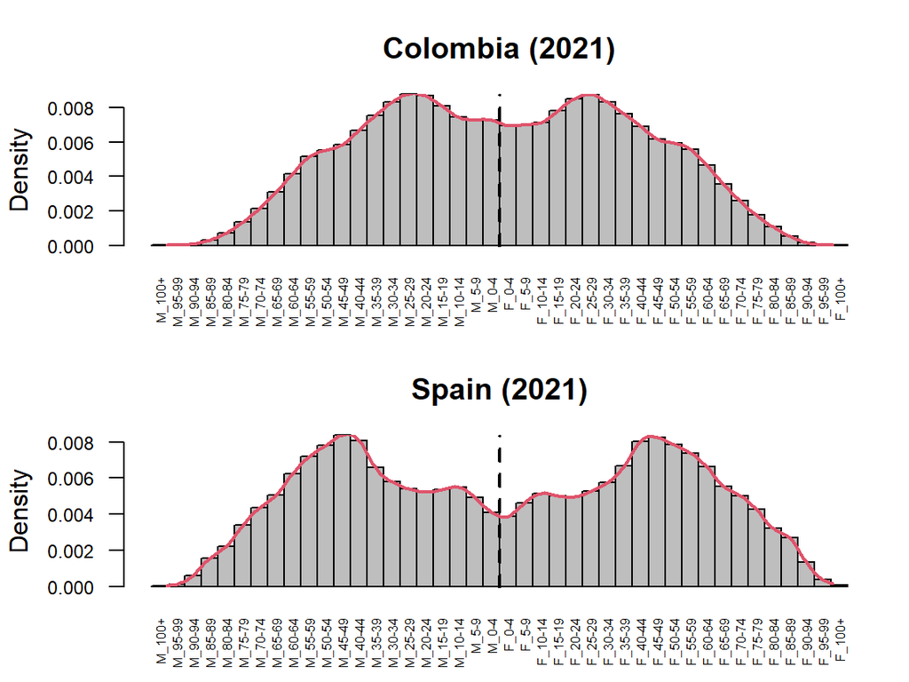

```r
max_age <- max(Age)
egAge.1 <- seq(-max_age+2,max_age-2,by=1)

par(mfrow=c(2,1), mar=c(3, 4, 3, 1) + 0.1)
max_age <- nag*5
year <- 2021
for (ctry in c('CO','ES')){
  name.country <- Country[ctry,1]
  pp <- as.numeric(PopPyrRel[ctry,as.character(year),])/5
  aux.spl <- smooth.spline(x=egAge,y=pp)
  pp.q.sm <- aux.spl$y
  pp.q.sm.1 <- predict(aux.spl,egAge.1)$y
  barplot(PopPyrRel[ctry,as.character(year),]/5,width=5,
          hor=F,beside=F,space=0,
          las=2, main=paste(name.country," (",year,")",sep=""),
          ylab="Density",
          xlab="",cex.names=.5, cex.axis = .75)
  abline(v=105,lty=2,lwd=2)
  lines(max_age+egAge.1,pp.q.sm.1,lwd=2,col=2)
}
```

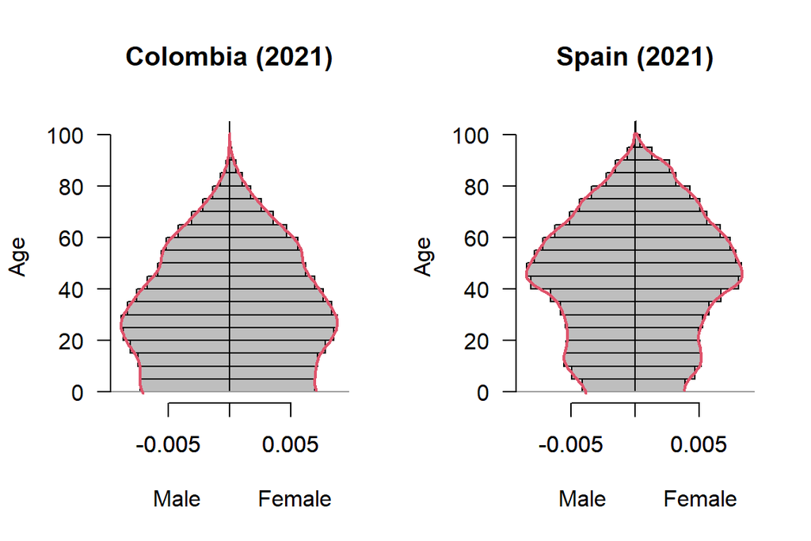

```r
par(mfrow=c(1,2))
max_age <- max(Age)
egAge.1 <- seq(-max_age+2,max_age-2,by=1)
nag.1 <- length(egAge.1)
nag.1.half <- round((nag.1+1)/2)

year <- 2021
for (ctry in c('CO','ES')){
  name.country <- Country[ctry,1]

  pp <- as.numeric(PopPyrRel[ctry,as.character(year),])/5
  aux.spl <- smooth.spline(x=egAge,y=pp)
  pp.q.sm <- aux.spl$y
  pp.q.sm.1 <- predict(aux.spl,egAge.1)$y

  male  <-as.numeric(PopPyrRel[ctry,as.character(year),nag:1])/5
  female<-as.numeric(PopPyrRel[ctry,as.character(year),nag+(1:nag)])/5
  max_x <- max(c(male, female))
  barplot(-male,width=5,hor=T,beside=F,space=0,
          xlim=max_x*1.1*c(-1,1),
          las=1, main=paste(name.country," (",year,")",sep=""),
          ylab="Age",
          xlab="    Male         Female")
  barplot(female,width=5,hor=T,beside=F,space=0,add=TRUE)
  abline(h=0,col=8)
  lines(-pp.q.sm.1[nag.1.half:1],-egAge.1[nag.1.half:1],lwd=2,col=2)
  lines(pp.q.sm.1[nag.1.half:nag.1],egAge.1[nag.1.half:nag.1],lwd=2,col=2)
  axis(2,labels=NULL,las=1)
}
```

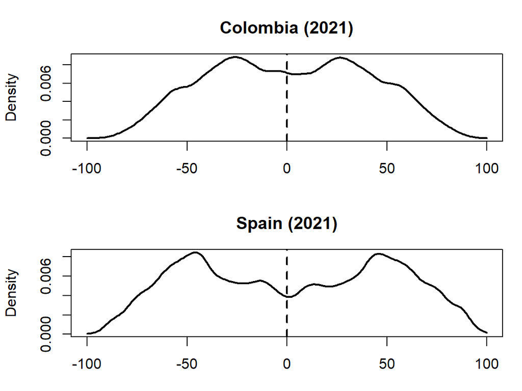

```r
max_age <- max(Age)
egAge.1 <- seq(-max_age+2.5,max_age-2.5,by=1)

par(mfrow=c(2,1), mar=c(3, 4, 3, 1) + 0.1)
max_age <- nag*5
year <- 2021
for (ctry in c('CO','ES')){
  name.country <- Country[ctry,1]
  pp <- as.numeric(PopPyrRel[ctry,as.character(year),])/5
  aux.spl <- smooth.spline(x=egAge,y=pp)
  pp.q.sm <- aux.spl$y
  pp.q.sm.1 <- predict(aux.spl,egAge.1)$y
  plot(egAge.1,pp.q.sm.1, type="l", lwd=2, col=1,
          main=paste(name.country," (",year,")",sep=""),
          ylab="Density")
  abline(v=0,lty=2,lwd=2)
}
```

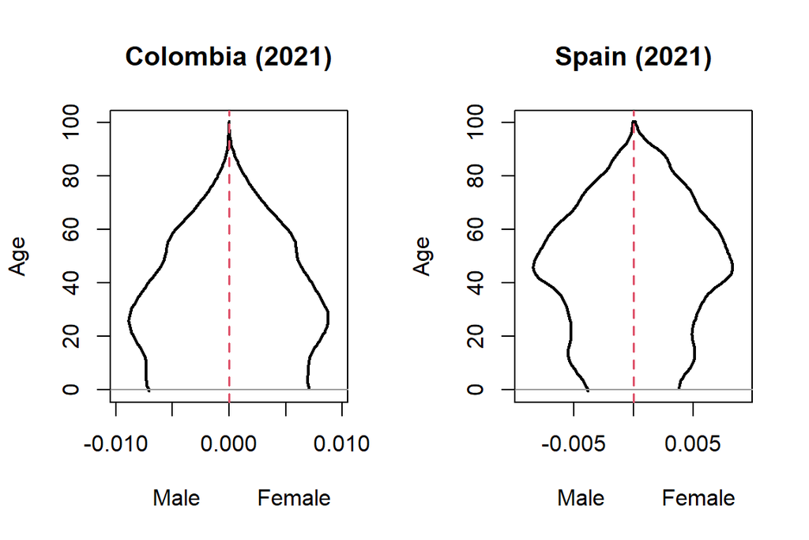

```r
par(mfrow=c(1,2))
max_age <- max(Age)
egAge.1 <- seq(-max_age+2,max_age-2,by=1)
nag.1 <- length(egAge.1)
nag.1.half <- round((nag.1+1)/2)

year <- 2021
for (ctry in c('CO','ES')){
  name.country <- Country[ctry,1]

  pp <- as.numeric(PopPyrRel[ctry,as.character(year),])/5
  aux.spl <- smooth.spline(x=egAge,y=pp)
  pp.q.sm <- aux.spl$y
  pp.q.sm.1 <- predict(aux.spl,egAge.1)$y

  male  <-as.numeric(PopPyrRel[ctry,as.character(year),nag:1])/5
  female<-as.numeric(PopPyrRel[ctry,as.character(year),nag+(1:nag)])/5
  max_x <- max(c(male, female))
  plot(-pp.q.sm.1[nag.1.half:1],-egAge.1[nag.1.half:1],
          type="l", lwd=2, col=1,
          xlim=max_x*1.1*c(-1,1),
          main=paste(name.country," (",year,")",sep=""),
          ylab="Age",
          xlab="    Male         Female")
  lines(pp.q.sm.1[nag.1.half:nag.1],egAge.1[nag.1.half:nag.1],
        lwd=2,col=1)
  abline(h=0,col=8)
  abline(v=0,col=2,lwd=1.5,lty=2)
}
```

Now, we smooth all the population pyramids in our cube population pyramid data sets:

```r
SmoothPopPyr <- function(PopPyr.5,
                         egAge.5=seq(-102.5,102.5,by=5),
                         egAge.1=seq(-102.5,102.5,by=1)){
  pp <- as.numeric(PopPyr.5)
  aux.spl <- smooth.spline(x=egAge.5,y=pp)
  pp.sm.1 <- predict(aux.spl,egAge.1)$y
  return(pp.sm.1)
}
if (!file.exists("Smoothed_Poulation_Pyramids.RData")){
  PopPyrSm <- array(data=NA, dim=c(nc,ny,nag.1),
                      dimnames = list(Country=CtryISO2,
                                      Year=as.character(Year),
                                      agAge=NULL))
  PopPyrRelSm <- PopPyrSm

  for (ctry in CtryISO2){
    for (year in Year){
      PopPyrSm[ctry,as.character(year),] <-
        SmoothPopPyr(PopPyr[ctry,as.character(year),]/5,
                     egAge.5 = egAge, egAge.1 = egAge.1)
      PopPyrRelSm[ctry,as.character(year),] <-
        SmoothPopPyr(PopPyrRel[ctry,as.character(year),]/5,
                     egAge.5 = egAge, egAge.1 = egAge.1)
    }
  }
  save(PopPyrSm, PopPyrRelSm, Year, egAge.1, Country,
       file="Smoothed_Poulation_Pyramids.RData")
}else{
  load("Smoothed_Poulation_Pyramids.RData")
}
```

# 4 Many smoothed population pyramids at the same plot

## 4.1 Many smoothed age-symmetric population histograms

First we plot many smoothed age-symmetric population histograms at the same graph:

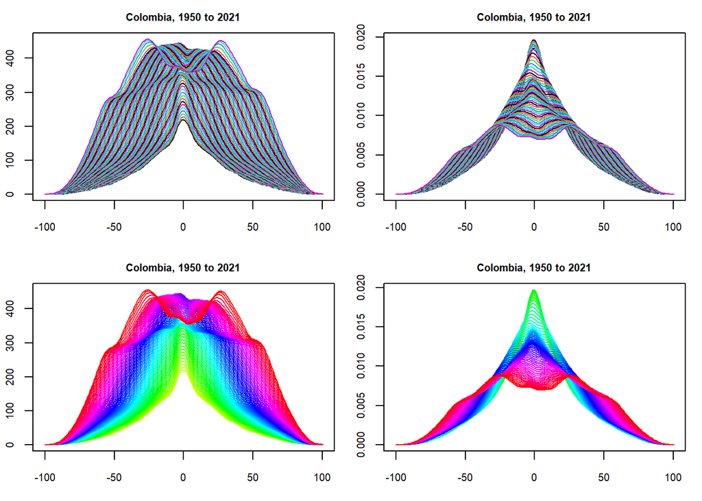

```r
par(mfrow=c(2,2),mar=c(3,2,2,1))
matplot(egAge.1,t(PopPyrSm['CO',,]), type="l", lty=1,
        xlab="egAge",ylab="Population (1000)",
        main=paste0(Country['CO',1],", ",Year[1]," to ",rev(Year)[1]),
        cex.main=.75,cex.lab=.75,cex.axis=.75)
matplot(egAge.1,t(PopPyrRelSm['CO',,]),type="l", lty=1,
        xlab="egAge",ylab="Density",
        main=paste0(Country['CO',1],", ",Year[1]," to ",rev(Year)[1]),
        cex.main=.75,cex.lab=.75,cex.axis=.75)
matplot(egAge.1,t(PopPyrSm['CO',,]), type="l", lty=1,
        col=rainbow(length(Year), start=.2, end=1),
        xlab="egAge",ylab="Population (1000)",
        main=paste0(Country['CO',1],", ",Year[1]," to ",rev(Year)[1]),
        cex.main=.75,cex.lab=.75,cex.axis=.75)
matplot(egAge.1,t(PopPyrRelSm['CO',,]),type="l", lty=1,
        col=rainbow(length(Year), start=.2, end=1),
        xlab="egAge",ylab="Density",
        main=paste0(Country['CO',1],", ",Year[1]," to ",rev(Year)[1]),
        cex.main=.75,cex.lab=.75,cex.axis=.75)
```

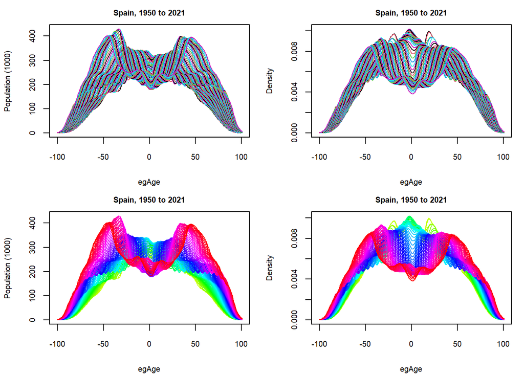

```r
par(mfrow=c(2,2),mar=c(4,4,2,1))
matplot(egAge.1,t(PopPyrSm['ES',,]), type="l", lty=1,
        xlab="egAge",ylab="Population (1000)",
        main=paste0(Country['ES',1],", ",Year[1]," to ",rev(Year)[1]),
        cex.main=.75,cex.lab=.75,cex.axis=.75)
matplot(egAge.1,t(PopPyrRelSm['ES',,]),type="l", lty=1,
        xlab="egAge",ylab="Density",
        main=paste0(Country['ES',1],", ",Year[1]," to ",rev(Year)[1]),
        cex.main=.75,cex.lab=.75,cex.axis=.75)
matplot(egAge.1,t(PopPyrSm['ES',,]), type="l", lty=1,
        col=rainbow(length(Year), start=.2, end=1),
        xlab="egAge",ylab="Population (1000)",
        main=paste0(Country['ES',1],", ",Year[1]," to ",rev(Year)[1]),
        cex.main=.75,cex.lab=.75,cex.axis=.75)
matplot(egAge.1,t(PopPyrRelSm['ES',,]),type="l", lty=1,
        col=rainbow(length(Year), start=.2, end=1),
        xlab="egAge",ylab="Density",
        main=paste0(Country['ES',1],", ",Year[1]," to ",rev(Year)[1]),
        cex.main=.75,cex.lab=.75,cex.axis=.75)
```

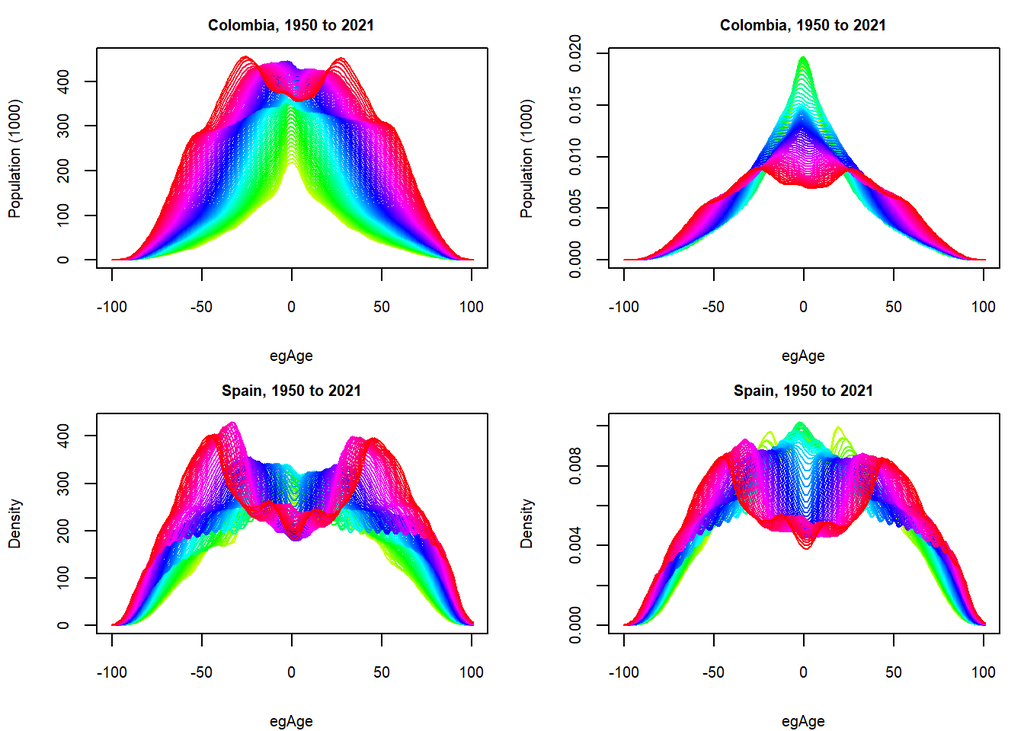

```r
par(mfrow=c(2,2),mar=c(4,4,2,1))
matplot(egAge.1,t(PopPyrSm['CO',,]), type="l", lty=1,
        col=rainbow(length(Year), start=.2, end=1),
        xlab="egAge",ylab="Population (1000)",
        main=paste0(Country['CO',1],", ",Year[1]," to ",rev(Year)[1]),
        cex.main=.75,cex.lab=.75,cex.axis=.75)
matplot(egAge.1,t(PopPyrRelSm['CO',,]), type="l", lty=1,
        col=rainbow(length(Year), start=.2, end=1),
        xlab="egAge",ylab="Population (1000)",
        main=paste0(Country['CO',1],", ",Year[1]," to ",rev(Year)[1]),
        cex.main=.75,cex.lab=.75,cex.axis=.75)
matplot(egAge.1,t(PopPyrSm['ES',,]),type="l", lty=1,
        col=rainbow(length(Year), start=.2, end=1),
        xlab="egAge",ylab="Density",
        main=paste0(Country['ES',1],", ",Year[1]," to ",rev(Year)[1]),
        cex.main=.75,cex.lab=.75,cex.axis=.75)
matplot(egAge.1,t(PopPyrRelSm['ES',,]),type="l", lty=1,
        col=rainbow(length(Year), start=.2, end=1),
        xlab="egAge",ylab="Density",
        main=paste0(Country['ES',1],", ",Year[1]," to ",rev(Year)[1]),
        cex.main=.75,cex.lab=.75,cex.axis=.75)
```

### 4.1.1 Alternative graphical representations

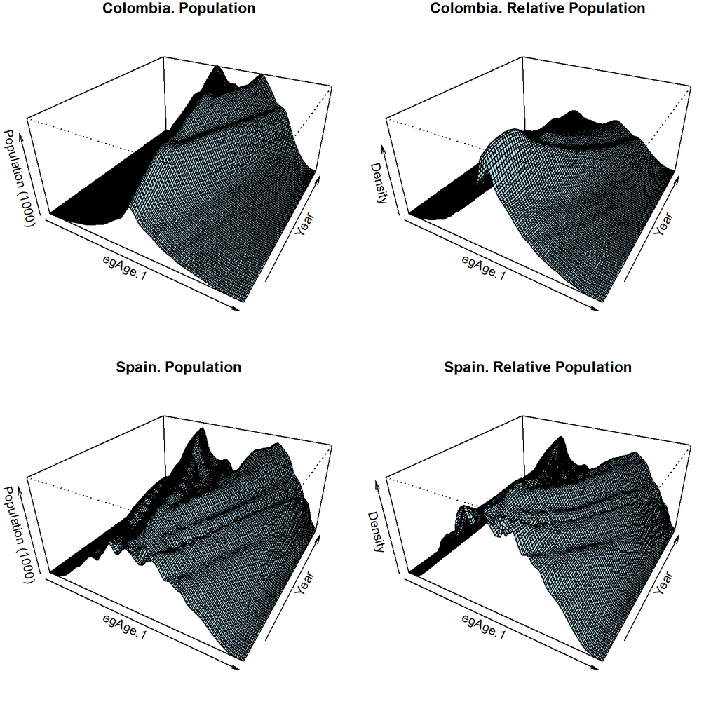

```r
par(mfrow=c(2,2),mar=c(1,1,1,1))
persp(egAge.1,Year, t(PopPyrSm['CO',,]),
      theta = 30, phi = 30, expand = 0.5, col = "lightblue",
      zlab="Population (1000)", main="Colombia. Population")
persp(egAge.1,Year, t(PopPyrRelSm['CO',,]),
      theta = 30, phi = 30, expand = 0.5, col = "lightblue",
      zlab="Density", main="Colombia. Relative Population")
persp(egAge.1,Year, t(PopPyrSm['ES',,]),
      theta = 30, phi = 30, expand = 0.5, col = "lightblue",
      zlab="Population (1000)", main="Spain. Population")
persp(egAge.1,Year, t(PopPyrRelSm['ES',,]),
      theta = 30, phi = 30, expand = 0.5, col = "lightblue",
      zlab="Density", main="Spain. Relative Population")
```

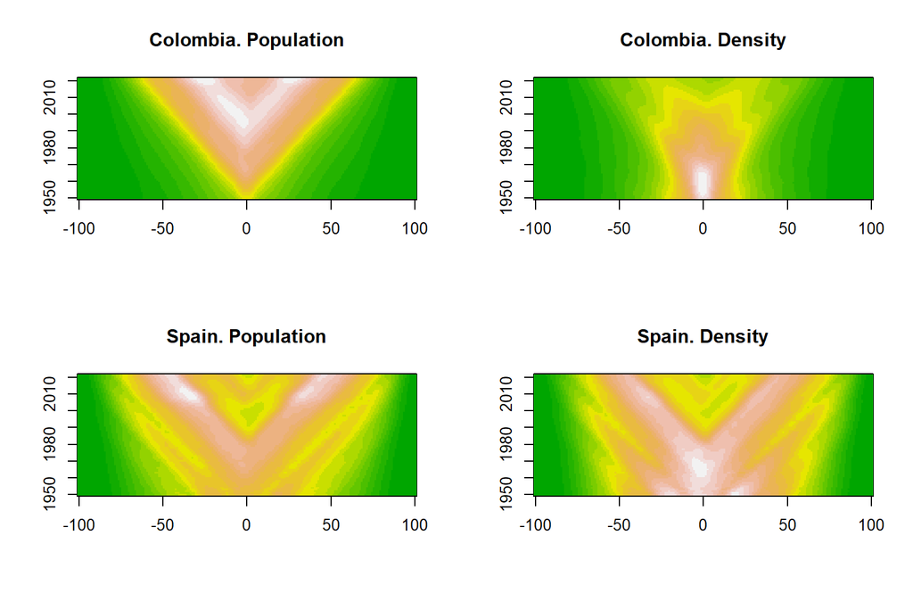

```r
par(mfrow=c(2,2))
image(egAge.1, Year, t(PopPyrSm['CO',,]), asp=1, xlab="", ylab="",
      col = terrain.colors(22), main="Colombia. Population")
image(egAge.1, Year, t(PopPyrRelSm['CO',,]), asp=1, xlab="", ylab="",
      col=terrain.colors(22), main="Colombia. Density")
image(egAge.1, Year, t(PopPyrSm['ES',,]), asp=1, xlab="", ylab="",
      col = terrain.colors(22), main="Spain. Population")
image(egAge.1, Year, t(PopPyrRelSm['ES',,]), asp=1, xlab="", ylab="",
      col=terrain.colors(22), main="Spain. Density")
```

## 4.2 Many smoothed population pyramids

Now we plot many smoothed population pyramids at the same graph:

```r
# matplot_pop_pyr_1y matplot for a population pyramids dataset
#                    with precision of 1 yr
# Arguments:
#
# age:   ages at which each row of matrix_pop_pyr is evaluated
# matrix_pop_pyr
#    Each row:    a population pyramid, first Male, then Female
#    Each column: an age, negative for Male, positive for Female
# orderM:  -1 (1) if Male is sorted in decreasing (increasing) order
matplot_pop_pyr_1y <-
  function(age=NULL, matrix_pop_pyr, orderM = -1,
           col=1:8, colM=col, colF=col, lty=1:8,
           main="",
           xlim=max(abs(matrix_pop_pyr)), ...){
  max_age <- dim(matrix_pop_pyr)[2]/2
  if (orderM==-1)
    matrix_pop_pyr[,1:max_age] <- matrix_pop_pyr[,max_age:1]
  n <- dim(matrix_pop_pyr)[1]
  pop_pyr <- as.numeric(matrix_pop_pyr[1,])
  if (is.null(age)){
    age <- 1:max_age -1
  } else {
    age <- age[age>0]
  }
  plot(-pop_pyr[1:max_age],age, type="l", lwd=1, col=colM[1],
       lty=lty[1],
       xlim=xlim*c(-1,1), ylim=c(0,100),
       xlab="",
       ylab="Age",
       main=main,
       axes=FALSE, ...)
  lines(pop_pyr[(max_age+1):(2*max_age)],age, lwd=1, lty=lty[1], col=colF[1], ...)
  abline(h=0)
  abline(v=0,col=8)
  segments(x0=rep(-.0005,5),y0=seq(20,100,by=20),x1=rep(.0005,5),col=8)
  axis(side=2, at=seq(0,100,by=20))
  #axis(side=1, at=seq(-.02,.02,by=.005), pos=0,
  #     labels=c(.02,NA,.01,NA,0,NA,.01,NA,.02))
  axis(side=1)
  legend("topleft","Male",bty="n")
  legend("topright","Female",bty="n")

  for (i in 2:n){
    lines(-matrix_pop_pyr[i,1:max_age],age, lwd=1, lty=lty[i%%length(lty)+1],
          col=colM[i%%length(col)+1], ...)
    lines(matrix_pop_pyr[i,(max_age+1):(2*max_age)],age, lwd=1, lty=lty[i%%length(lty)+1],
          col=colF[i%%length(col)+1], ...)
  }
}

# lines_pop_pyr_1y Adds to an existing plot a lines representing
#                  a population pyramids, precision of 1 yr
# Arguments:
#
# age:   ages at which each row of matrix_pop_pyr is evaluated
# pop_pyr:  a population pyramid, first Male, then Female
# orderM:  -1 (1) if Male is sorted in decreasing (increasing) order
lines_pop_pyr <- function(age=NULL, pop_pyr, orderM = -1,
                          lty=1, lwd=1,
                          col=1, colM=col, colF=col, ...){
  pop_pyr <- as.numeric(pop_pyr)
  max_age <- length(pop_pyr)/2
  if (orderM==-1) pop_pyr[1:max_age] <- pop_pyr[max_age:1]
  if (is.null(age)) age <- 1:max_age -1
  lines(-pop_pyr[1:max_age],age, lwd=lwd, lty=lty, col=colM, ...)
  lines(pop_pyr[(max_age+1):(2*max_age)],age, lwd=lwd, lty=lty, col=colF, ...)
}
```

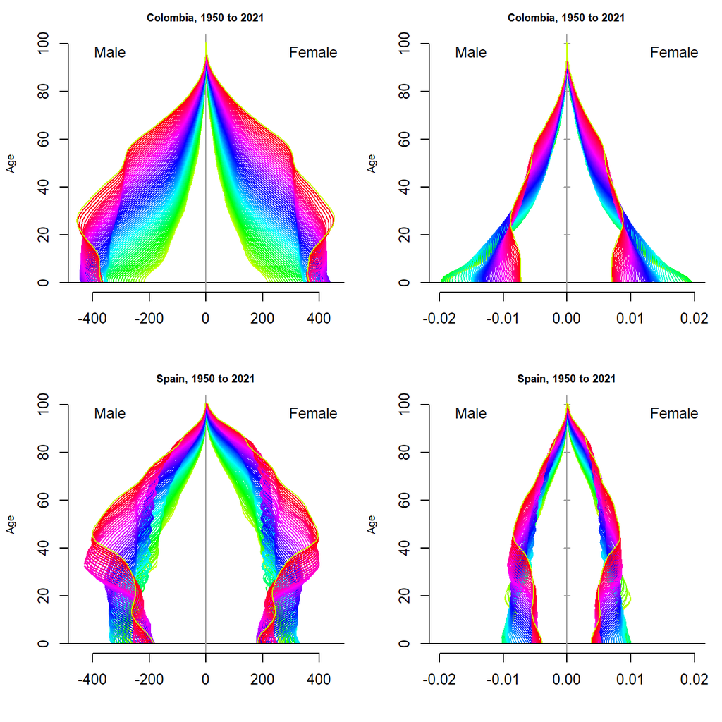

```r
par(mfrow=c(2,2),mar=c(4,4,2,1))
matplot_pop_pyr_1y(egAge.1,PopPyrSm['CO',,], lty=1,
                    xlim=450,
       col=rainbow(length(Year), start=.2, end=1),
        main=paste0(Country['CO',1],", ",Year[1]," to ",rev(Year)[1]),
        cex.main=.75,cex.lab=.75,cex.axis=.75)
matplot_pop_pyr_1y(egAge.1,PopPyrRelSm['CO',,], lty=1,
                   xlim=.02,
        col=rainbow(length(Year), start=.2, end=1),
        main=paste0(Country['CO',1],", ",Year[1]," to ",rev(Year)[1]),
        cex.main=.75,cex.lab=.75,cex.axis=.75)
matplot_pop_pyr_1y(egAge.1,PopPyrSm['ES',,], lty=1,
                   xlim=450,
        col=rainbow(length(Year), start=.2, end=1),
        main=paste0(Country['ES',1],", ",Year[1]," to ",rev(Year)[1]),
        cex.main=.75,cex.lab=.75,cex.axis=.75)
matplot_pop_pyr_1y(egAge.1,PopPyrRelSm['ES',,], lty=1,
                   xlim=.02,
        col=rainbow(length(Year), start=.2, end=1),
        main=paste0(Country['ES',1],", ",Year[1]," to ",rev(Year)[1]),
        cex.main=.75,cex.lab=.75,cex.axis=.75)
```

### 4.2.1 Animated graphics for population pyramids

```r
library(gifski)
```

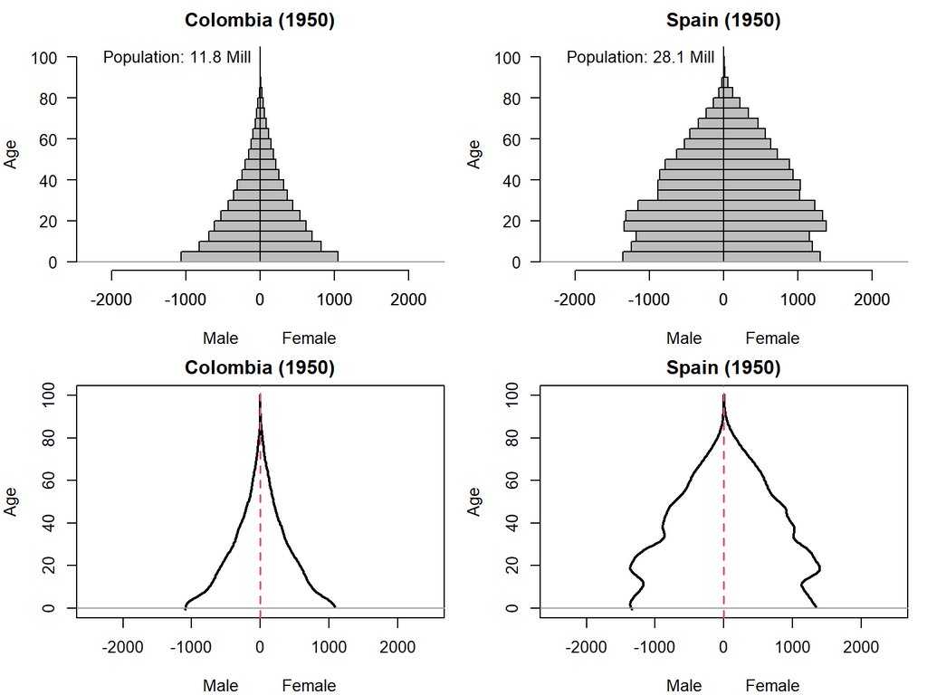

```r
par(mfrow=c(2,2),mar=c(4,4,2,1))
max_x <- 2250
for (year in Year) {
  for (ctry in c('CO','ES')){
    name.country <- Country[ctry,1]
    male  <-as.numeric(PopPyr[ctry,as.character(year),nag:1])
    female<-as.numeric(PopPyr[ctry,as.character(year),nag+(1:nag)])
    barplot(-male,width=5,hor=T,beside=F,space=0,
            xlim=max_x*1.1*c(-1,1),
            las=1, main=paste(name.country," (",year,")",sep=""),
            ylab="Age",
            xlab="    Male         Female")
    barplot(female,width=5,hor=T,beside=F,space=0,add=TRUE)
    abline(h=0,col=8)
    axis(2,labels=NULL,las=1)
    text(-max_x,100,
      paste("Population:", round(sum(male+female)/1e3,1),"Mill"),
      pos=4)
  }
  for (ctry in c('CO','ES')){
    name.country <- Country[ctry,1]

    pp <- as.numeric(PopPyr[ctry,as.character(year),])
    aux.spl <- smooth.spline(x=egAge,y=pp)
    pp.q.sm <- aux.spl$y
    pp.q.sm.1 <- predict(aux.spl,egAge.1)$y

    male  <-as.numeric(PopPyr[ctry,as.character(year),nag:1])
    female<-as.numeric(PopPyr[ctry,as.character(year),nag+(1:nag)])
    plot(-pp.q.sm.1[nag.1.half:1],-egAge.1[nag.1.half:1],
            type="l", lwd=2, col=1,
            xlim=max_x*1.1*c(-1,1),
            main=paste(name.country," (",year,")",sep=""),
            ylab="Age",
            xlab="    Male         Female")
    lines(pp.q.sm.1[nag.1.half:nag.1],egAge.1[nag.1.half:nag.1],
          lwd=2,col=1)
    abline(h=0,col=8)
    abline(v=0,col=2,lwd=1.5,lty=2)
  }
}
```

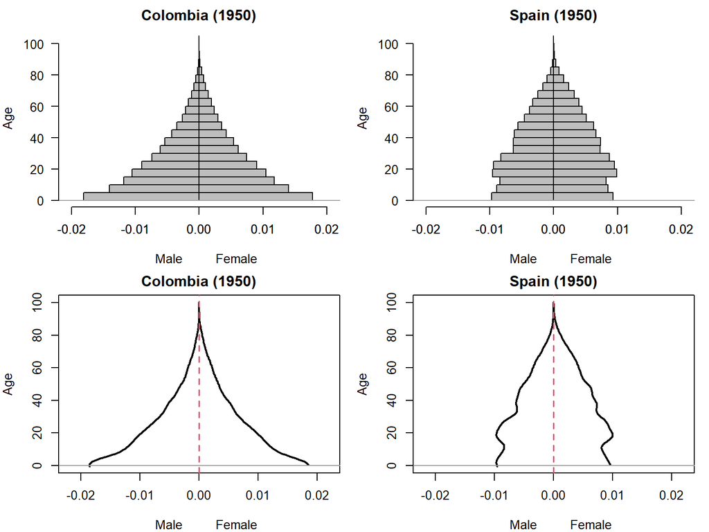

```r
par(mfrow=c(2,2),mar=c(4,4,2,1))
max_x <- 0.02
for (year in Year) {
  for (ctry in c('CO','ES')){
    name.country <- Country[ctry,1]
    male  <-as.numeric(PopPyrRel[ctry,as.character(year),nag:1])/5
    female<-as.numeric(PopPyrRel[ctry,as.character(year),nag+(1:nag)])/5
    barplot(-male,width=5,hor=T,beside=F,space=0,
            xlim=max_x*1.1*c(-1,1),
            las=1, main=paste(name.country," (",year,")",sep=""),
            ylab="Age",
            xlab="    Male         Female")
    barplot(female,width=5,hor=T,beside=F,space=0,add=TRUE)
    abline(h=0,col=8)
    axis(2,labels=NULL,las=1)
  }
  for (ctry in c('CO','ES')){
    name.country <- Country[ctry,1]

    pp <- as.numeric(PopPyrRel[ctry,as.character(year),])/5
    aux.spl <- smooth.spline(x=egAge,y=pp)
    pp.q.sm <- aux.spl$y
    pp.q.sm.1 <- predict(aux.spl,egAge.1)$y

    male  <-as.numeric(PopPyrRel[ctry,as.character(year),nag:1])/5
    female<-as.numeric(PopPyrRel[ctry,as.character(year),nag+(1:nag)])/5
    plot(-pp.q.sm.1[nag.1.half:1],-egAge.1[nag.1.half:1],
            type="l", lwd=2, col=1,
            xlim=max_x*1.1*c(-1,1),
            main=paste(name.country," (",year,")",sep=""),
            ylab="Age",
            xlab="    Male         Female")
    lines(pp.q.sm.1[nag.1.half:nag.1],egAge.1[nag.1.half:nag.1],
          lwd=2,col=1)
    abline(h=0,col=8)
    abline(v=0,col=2,lwd=1.5,lty=2)
  }
}
```